# regression_sector_specific

# Employment to population ratio

## Crop sector

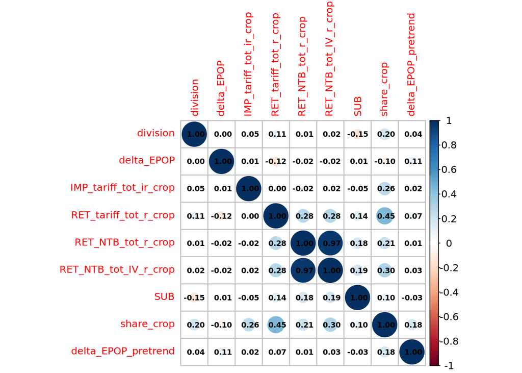

```
## NOTE: 732 observations removed because of NA values (RHS: 732).
```

```
## NOTE: 732 observations removed because of NA values (RHS: 732).
## NOTE: 732 observations removed because of NA values (RHS: 732).
## NOTE: 732 observations removed because of NA values (RHS: 732).
```

reg1

reg2

reg3

reg4

Dependent Var.:

delta_EPOP

delta_EPOP

delta_EPOP

delta_EPOP

IMP_tariff_tot_ir_crop

0.0003 (0.0015)

0.0015 (0.0015)

0.0017 (0.0014)

0.0019 (0.0016)

RET_tariff_tot_r_crop

-0.0016*** (0.0005)

-0.0012* (0.0006)

-0.0013* (0.0006)

-0.0013* (0.0006)

RET_NTB_tot_r_crop

0.0001 (0.0002)

0.0002 (0.0002)

0.0002 (0.0002)

0.0002 (0.0002)

SUB

1.26e-7* (6.39e-8)

1.33e-7* (6.47e-8)

1.91e-7* (7.74e-8)

2.19e-7** (7.72e-8)

as.factor(year)2018 x share_crop

-0.0022 (0.0030)

-0.0019 (0.0032)

-0.0036 (0.0034)

as.factor(year)2019 x share_crop

-0.0064 (0.0052)

-0.0063 (0.0053)

-0.0081 (0.0055)

year x delta_EPOP_pretrend

7.44e-5* (3.22e-5)

Fixed-Effects:

——————-

——————

——————

——————-

Year FE

Yes

Yes

Yes

Yes

Sector x year-month FE

No

Yes

Yes

Yes

Census division x year-month FE

No

No

Yes

Yes

Pre-trend CZ outcome 2017

No

No

No

Yes

year

Yes

Yes

Yes

Yes

________________________________

___________________

__________________

__________________

___________________

S.E.: Clustered

by: fips

by: fips

by: fips

by: fips

Observations

5,548

5,548

5,548

5,548

R2

0.01655

0.02041

0.02383

0.03982

Adj. R2

0.01566

0.01917

0.01977

0.03565

F-test

9.3328

8.2545

2.9439

4.7915

F-test, p-value

7.89e-9

5.36e-10

3.32e-6

1.6e-13

RMSE

0.00231

0.00231

0.00231

0.00229

```
## NOTE: 732 observations removed because of NA values (RHS: 732).
## NOTE: 732 observations removed because of NA values (RHS: 732).
## NOTE: 732 observations removed because of NA values (RHS: 732).
## NOTE: 732 observations removed because of NA values (RHS: 732).
```

reg1

reg2

reg3

reg4

Dependent Var.:

delta_EPOP

delta_EPOP

delta_EPOP

delta_EPOP

IMP_tariff_tot_ir_crop

0.0003 (0.0015)

0.0015 (0.0015)

0.0017 (0.0014)

0.0019 (0.0016)

RET_tariff_tot_r_crop

-0.0016*** (0.0005)

-0.0012* (0.0006)

-0.0013* (0.0006)

-0.0013* (0.0006)

RET_NTB_tot_IV_r_crop

0.0002 (0.0004)

0.0006 (0.0005)

0.0005 (0.0005)

0.0006 (0.0005)

SUB

1.26e-7. (6.47e-8)

1.29e-7* (6.51e-8)

1.85e-7* (7.79e-8)

2.12e-7** (7.77e-8)

as.factor(year)2018 x share_crop

-0.0024 (0.0031)

-0.0021 (0.0032)

-0.0038 (0.0035)

as.factor(year)2019 x share_crop

-0.0067 (0.0053)

-0.0066 (0.0054)

-0.0085 (0.0056)

year x delta_EPOP_pretrend

7.46e-5* (3.22e-5)

Fixed-Effects:

——————-

——————

——————

——————-

Year FE

Yes

Yes

Yes

Yes

Sector x year-month FE

No

Yes

Yes

Yes

Census division x year-month FE

No

No

Yes

Yes

Pre-trend CZ outcome 2017

No

No

No

Yes

year

Yes

Yes

Yes

Yes

________________________________

___________________

__________________

__________________

___________________

S.E.: Clustered

by: fips

by: fips

by: fips

by: fips

Observations

5,548

5,548

5,548

5,548

R2

0.01654

0.02067

0.02411

0.04014

Adj. R2

0.01565

0.01943

0.02004

0.03597

F-test

9.3288

8.3611

2.9780

4.8316

F-test, p-value

7.96e-9

3.83e-10

2.54e-6

1.1e-13

RMSE

0.00231

0.00231

0.00231

0.00229

## Livestock sector

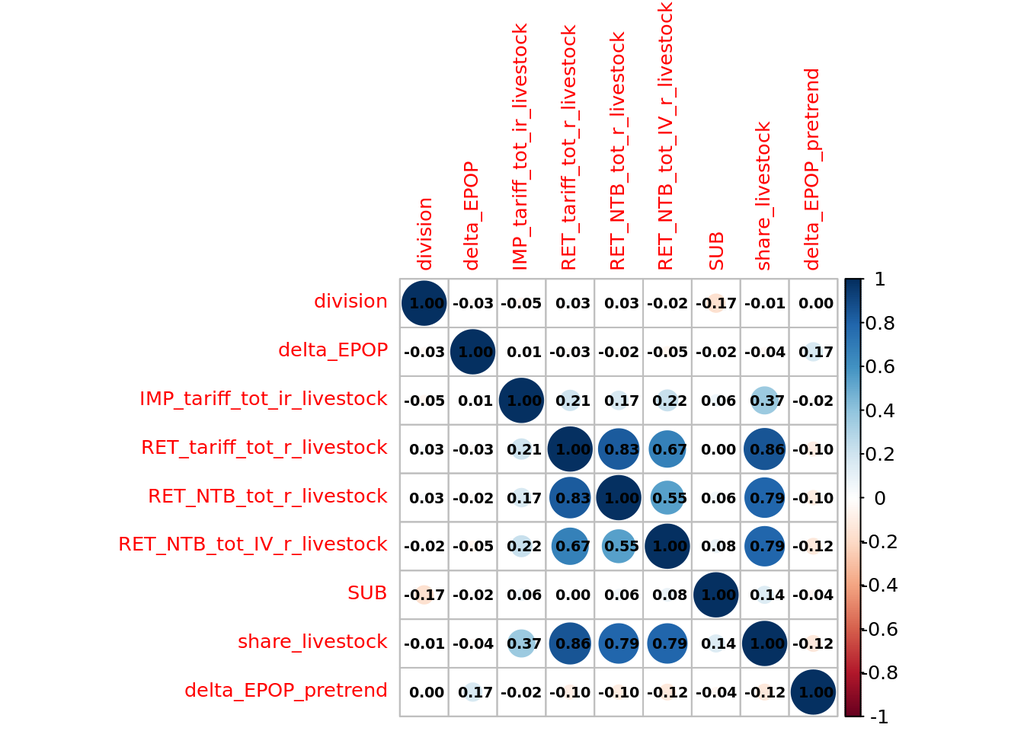

```
## NOTE: 1,480 observations removed because of NA values (RHS: 1,480).
## NOTE: 1,480 observations removed because of NA values (RHS: 1,480).
## NOTE: 1,480 observations removed because of NA values (RHS: 1,480).
## NOTE: 1,480 observations removed because of NA values (RHS: 1,480).
```

reg1

reg2

reg3

reg4

Dependent Var.:

delta_EPOP

delta_EPOP

delta_EPOP

delta_EPOP

IMP_tariff_tot_ir_livestock

0.0010 (0.0014)

0.0019 (0.0029)

0.0019 (0.0029)

0.0015 (0.0029)

RET_tariff_tot_r_livestock

-0.0028 (0.0046)

0.0009 (0.0103)

0.0010 (0.0105)

0.0004 (0.0106)

RET_NTB_tot_r_livestock

0.0005 (0.0094)

0.0040 (0.0125)

0.0071 (0.0128)

0.0079 (0.0128)

SUB

-1.47e-7 (1.64e-7)

-9.1e-8 (1.74e-7)

-1.94e-7 (1.72e-7)

-1.74e-7 (1.71e-7)

as.factor(year)2018 x share_livestock

-0.0047 (0.0111)

-0.0057 (0.0112)

-0.0038 (0.0113)

as.factor(year)2019 x share_livestock

-0.0062 (0.0168)

-0.0078 (0.0171)

-0.0057 (0.0171)

year x delta_EPOP_pretrend

9.26e-5* (3.87e-5)

Fixed-Effects:

——————

—————–

——————

——————

Year FE

Yes

Yes

Yes

Yes

Sector x year-month FE

No

Yes

Yes

Yes

Census division x year-month FE

No

No

Yes

Yes

Pre-trend CZ outcome 2017

No

No

No

Yes

year

Yes

Yes

Yes

Yes

_____________________________________

__________________

_________________

__________________

__________________

S.E.: Clustered

by: fips

by: fips

by: fips

by: fips

Observations

4,800

4,800

4,800

4,800

R2

0.00148

0.00233

0.00819

0.03412

Adj. R2

0.00044

0.00087

0.00341

0.02926

F-test

0.71208

0.79884

0.86107

3.5308

F-test, p-value

0.61433

0.58821

0.65337

1.57e-8

RMSE

0.00433

0.00433

0.00431

0.00426

```
## NOTE: 1,480 observations removed because of NA values (RHS: 1,480).
## NOTE: 1,480 observations removed because of NA values (RHS: 1,480).
## NOTE: 1,480 observations removed because of NA values (RHS: 1,480).
## NOTE: 1,480 observations removed because of NA values (RHS: 1,480).
```

reg1

reg2

reg3

reg4

Dependent Var.:

delta_EPOP

delta_EPOP

delta_EPOP

delta_EPOP

IMP_tariff_tot_ir_livestock

0.0012 (0.0014)

0.0008 (0.0042)

0.0007 (0.0041)

0.0004 (0.0041)

RET_tariff_tot_r_livestock

0.0011 (0.0058)

0.0004 (0.0133)

0.0011 (0.0133)

0.0009 (0.0133)

RET_NTB_tot_IV_r_livestock

-0.0093 (0.0112)

-0.0115 (0.0226)

-0.0123 (0.0224)

-0.0108 (0.0222)

SUB

-1.01e-7 (1.53e-7)

-1.06e-7 (1.95e-7)

-2.28e-7 (1.94e-7)

-2.04e-7 (1.93e-7)

as.factor(year)2018 x share_livestock

0.0006 (0.0164)

0.0002 (0.0163)

0.0016 (0.0161)

as.factor(year)2019 x share_livestock

0.0032 (0.0291)

0.0024 (0.0289)

0.0034 (0.0286)

year x delta_EPOP_pretrend

9.17e-5* (3.84e-5)

Fixed-Effects:

——————

——————

——————

——————

Year FE

Yes

Yes

Yes

Yes

Sector x year-month FE

No

Yes

Yes

Yes

Census division x year-month FE

No

No

Yes

Yes

Pre-trend CZ outcome 2017

No

No

No

Yes

year

Yes

Yes

Yes

Yes

_____________________________________

__________________

__________________

__________________

__________________

S.E.: Clustered

by: fips

by: fips

by: fips

by: fips

Observations

4,800

4,800

4,800

4,800

R2

0.00380

0.00398

0.00996

0.03536

Adj. R2

0.00276

0.00253

0.00519

0.03051

F-test

1.8301

1.3708

1.0489

3.6637

F-test, p-value

0.10365

0.21326

0.39775

4.94e-9

RMSE

0.00432

0.00432

0.00431

0.00426

## non ag

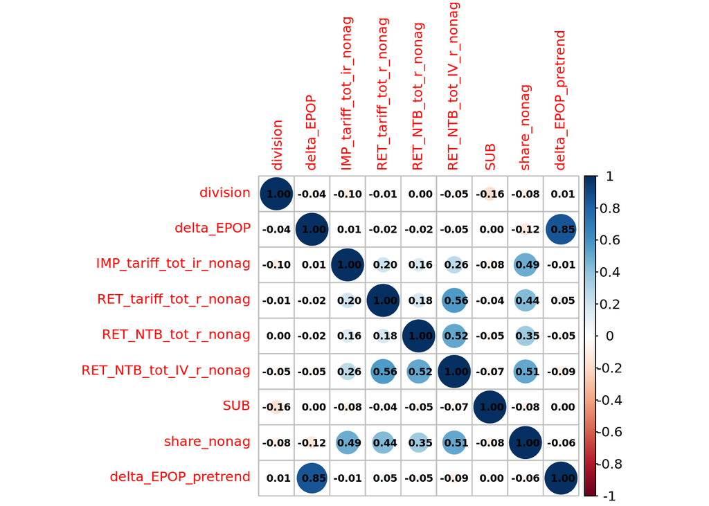

```
## NOTE: 198 observations removed because of NA values (RHS: 198).
```

```
## NOTE: 200 observations removed because of NA values (RHS: 200).
## NOTE: 200 observations removed because of NA values (RHS: 200).
## NOTE: 200 observations removed because of NA values (RHS: 200).
```

reg1

reg2

reg3

reg4

Dependent Var.:

delta_EPOP

delta_EPOP

delta_EPOP

delta_EPOP

IMP_tariff_tot_ir_nonag

0.0012 (0.0019)

0.0149 (0.0145)

0.0137 (0.0138)

0.0088** (0.0031)

RET_tariff_tot_r_nonag

-0.0110 (0.0098)

0.0415 (0.0433)

0.0443 (0.0443)

-0.0159 (0.0182)

RET_NTB_tot_r_nonag

-0.0032 (0.0066)

0.0079 (0.0055)

0.0096 (0.0065)

0.0135*** (0.0033)

as.factor(year)2018 x share_nonag

-0.0495 (0.0483)

-0.0539 (0.0509)

-0.0326*** (0.0095)

as.factor(year)2019 x share_nonag

-0.0821 (0.0764)

-0.0842 (0.0771)

-0.0464*** (0.0132)

year x delta_EPOP_pretrend

0.0004*** (6.54e-5)

Fixed-Effects:

—————-

—————-

—————-

——————-

Year FE

Yes

Yes

Yes

Yes

Sector x year-month FE

No

Yes

Yes

Yes

Census division x year-month FE

No

No

Yes

Yes

Pre-trend CZ outcome 2017

No

No

No

Yes

year

Yes

Yes

Yes

Yes

_________________________________

________________

________________

________________

___________________

S.E.: Clustered

by: fips

by: fips

by: fips

by: fips

Observations

6,082

6,080

6,080

6,080

R2

0.00074

0.02895

0.03877

0.74761

Adj. R2

8.39e-5

0.02799

0.03528

0.74665

F-test

0.56408

15.100

5.5714

391.38

F-test, p-value

0.68875

4.17e-17

1.38e-15

0e-16

RMSE

0.02162

0.02132

0.02121

0.01087

```
## NOTE: 198 observations removed because of NA values (RHS: 198).
## NOTE: 200 observations removed because of NA values (RHS: 200).
## NOTE: 200 observations removed because of NA values (RHS: 200).
## NOTE: 200 observations removed because of NA values (RHS: 200).
```

reg1

reg2

reg3

reg4

Dependent Var.:

delta_EPOP

delta_EPOP

delta_EPOP

delta_EPOP

IMP_tariff_tot_ir_nonag

0.0017 (0.0025)

0.0150 (0.0143)

0.0138 (0.0135)

0.0110*** (0.0030)

RET_tariff_tot_r_nonag

0.0063 (0.0188)

0.0354 (0.0436)

0.0371 (0.0443)

-0.0482. (0.0251)

RET_NTB_tot_IV_r_nonag

-0.0165 (0.0242)

0.0082 (0.0050)

0.0093. (0.0056)

0.0437*** (0.0105)

as.factor(year)2018 x share_nonag

-0.0481 (0.0458)

-0.0519 (0.0481)

-0.0381*** (0.0100)

as.factor(year)2019 x share_nonag

-0.0820 (0.0731)

-0.0836 (0.0735)

-0.0648*** (0.0137)

year x delta_EPOP_pretrend

0.0004*** (6.36e-5)

Fixed-Effects:

—————-

—————-

—————-

——————-

Year FE

Yes

Yes

Yes

Yes

Sector x year-month FE

No

Yes

Yes

Yes

Census division x year-month FE

No

No

Yes

Yes

Pre-trend CZ outcome 2017

No

No

No

Yes

year

Yes

Yes

Yes

Yes

_________________________________

________________

________________

________________

___________________

S.E.: Clustered

by: fips

by: fips

by: fips

by: fips

Observations

6,082

6,080

6,080

6,080

R2

0.00291

0.02805

0.03735

0.75713

Adj. R2

0.00225

0.02709

0.03386

0.75621

F-test

2.2145

14.616

5.3597

411.90

F-test, p-value

0.06501

1.6e-16

9e-15

0e-16

RMSE

0.02160

0.02133

0.02123

0.01066

# Log employment change

## Crop sector

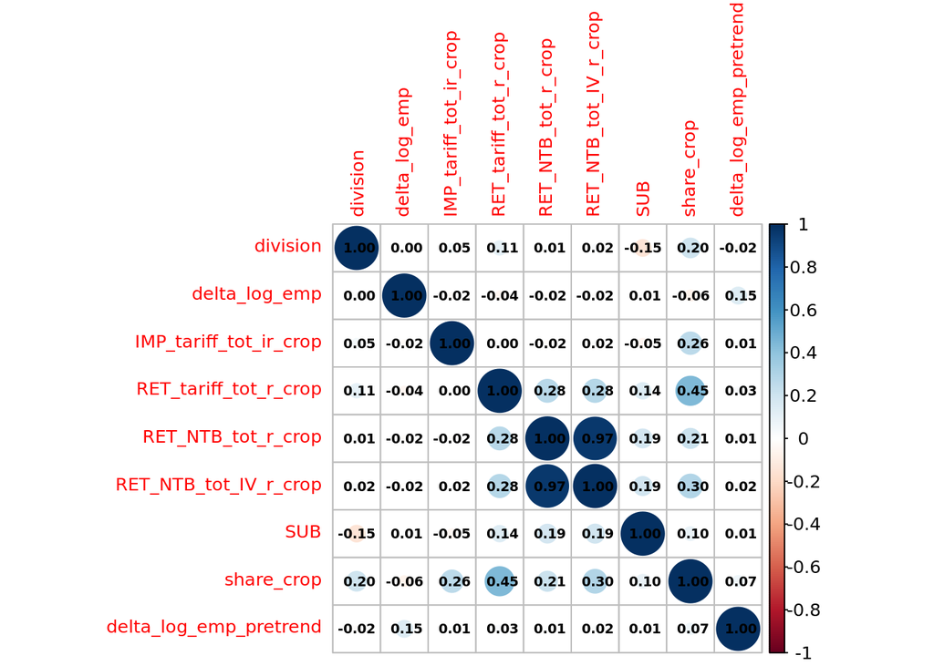

```
## NOTE: 885 observations removed because of NA values (LHS: 618, RHS: 732).
## NOTE: 885 observations removed because of NA values (LHS: 618, RHS: 732).
## NOTE: 885 observations removed because of NA values (LHS: 618, RHS: 732).
```

```
## NOTE: 902 observations removed because of NA values (LHS: 618, RHS: 868).
```

reg1

reg2

reg3

reg4

Dependent Var.:

delta_log_emp

delta_log_emp

delta_log_emp

delta_log_emp

IMP_tariff_tot_ir_crop

-0.2625. (0.1405)

-0.0897 (0.1224)

-0.1071 (0.1311)

-0.1049 (0.1337)

RET_tariff_tot_r_crop

-0.1204*** (0.0344)

-0.0563 (0.0378)

-0.0482 (0.0391)

-0.0381 (0.0389)

RET_NTB_tot_r_crop

-0.0225 (0.0237)

-0.0093 (0.0223)

-0.0208 (0.0228)

-0.0184 (0.0232)

SUB

1.7e-5 (1.16e-5)

1.84e-5 (1.16e-5)

3.3e-5* (1.41e-5)

3.35e-5* (1.39e-5)

as.factor(year)2018 x share_crop

-0.5615** (0.1718)

-0.6138** (0.1996)

-0.8190*** (0.1993)

as.factor(year)2019 x share_crop

-0.9158** (0.2885)

-0.9430** (0.2924)

-1.165*** (0.2952)

year x delta_log_emp_pretrend

8.51e-5*** (1.84e-5)

Fixed-Effects:

——————-

——————

——————

——————–

Year FE

Yes

Yes

Yes

Yes

Sector x year-month FE

No

Yes

Yes

Yes

Census division x year-month FE

No

No

Yes

Yes

Pre-trend CZ outcome 2017

No

No

No

Yes

year

Yes

Yes

Yes

Yes

________________________________

___________________

__________________

__________________

____________________

S.E.: Clustered

by: fips

by: fips

by: fips

by: fips

Observations

5,395

5,395

5,395

5,378

R2

0.00335

0.00524

0.00847

0.03341

Adj. R2

0.00242

0.00395

0.00422

0.02908

F-test

1.8139

2.0336

1.0023

3.8754

F-test, p-value

0.10672

0.04756

0.45826

7.22e-10

RMSE

0.53386

0.53335

0.53248

0.52605

```
## NOTE: 885 observations removed because of NA values (LHS: 618, RHS: 732).
```

```
## NOTE: 885 observations removed because of NA values (LHS: 618, RHS: 732).
## NOTE: 885 observations removed because of NA values (LHS: 618, RHS: 732).
```

```
## NOTE: 902 observations removed because of NA values (LHS: 618, RHS: 868).
```

reg1

reg2

reg3

reg4

Dependent Var.:

delta_log_emp

delta_log_emp

delta_log_emp

delta_log_emp

IMP_tariff_tot_ir_crop

-0.2595. (0.1400)

-0.0850 (0.1218)

-0.1022 (0.1305)

-0.1001 (0.1331)

RET_tariff_tot_r_crop

-0.1215*** (0.0345)

-0.0595 (0.0374)

-0.0521 (0.0388)

-0.0418 (0.0387)

RET_NTB_tot_IV_r_crop

-0.0371 (0.0475)

0.0128 (0.0461)

-0.0074 (0.0474)

-0.0033 (0.0487)

SUB

1.68e-5 (1.17e-5)

1.75e-5 (1.17e-5)

3.18e-5* (1.42e-5)

3.23e-5* (1.4e-5)

as.factor(year)2018 x share_crop

-0.5724** (0.1742)

-0.6211** (0.2023)

-0.8271*** (0.2019)

as.factor(year)2019 x share_crop

-0.9375** (0.2920)

-0.9602** (0.2971)

-1.184*** (0.2999)

year x delta_log_emp_pretrend

8.51e-5*** (1.84e-5)

Fixed-Effects:

——————-

——————

——————

——————–

Year FE

Yes

Yes

Yes

Yes

Sector x year-month FE

No

Yes

Yes

Yes

Census division x year-month FE

No

No

Yes

Yes

Pre-trend CZ outcome 2017

No

No

No

Yes

year

Yes

Yes

Yes

Yes

________________________________

___________________

__________________

__________________

____________________

S.E.: Clustered

by: fips

by: fips

by: fips

by: fips

Observations

5,395

5,395

5,395

5,378

R2

0.00332

0.00524

0.00840

0.03336

Adj. R2

0.00240

0.00394

0.00416

0.02902

F-test

1.7998

2.0308

0.99470

3.8693

F-test, p-value

0.10951

0.04788

0.46837

7.62e-10

RMSE

0.53386

0.53335

0.53250

0.52606

## Livestock sector

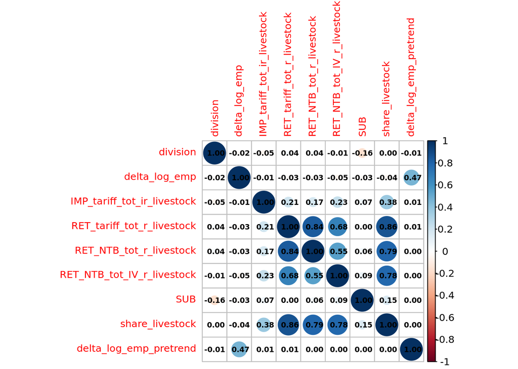

```
## NOTE: 1,777 observations removed because of NA values (LHS: 1,396, RHS: 1,480).
## NOTE: 1,777 observations removed because of NA values (LHS: 1,396, RHS: 1,480).
## NOTE: 1,777 observations removed because of NA values (LHS: 1,396, RHS: 1,480).
```

```
## NOTE: 1,793 observations removed because of NA values (LHS: 1,396, RHS: 1,732).
```

reg1

reg2

reg3

reg4

Dependent Var.:

delta_log_emp

delta_log_emp

delta_log_emp

delta_log_emp

IMP_tariff_tot_ir_livestock

-0.0498 (0.0933)

0.1354 (0.1116)

0.1208 (0.1174)

0.0575 (0.1203)

RET_tariff_tot_r_livestock

-0.2458 (0.2889)

0.5255 (0.3870)

0.4534 (0.4051)

0.2148 (0.4122)

RET_NTB_tot_r_livestock

-0.5819 (0.9726)

0.1314 (0.9464)

0.2465 (0.9942)

0.2073 (1.070)

SUB

-4.27e-5* (1.89e-5)

-2.97e-5 (1.84e-5)

-3.23e-5. (1.9e-5)

-2.73e-5 (1.95e-5)

as.factor(year)2018 x share_livestock

-1.094** (0.3951)

-1.097** (0.3993)

-0.9248* (0.3819)

as.factor(year)2019 x share_livestock

-1.210* (0.4745)

-1.134* (0.4782)

-0.9220* (0.4603)

year x delta_log_emp_pretrend

0.0002** (8.91e-5)

Fixed-Effects:

——————-

——————

——————

——————

Year FE

Yes

Yes

Yes

Yes

Sector x year-month FE

No

Yes

Yes

Yes

Census division x year-month FE

No

No

Yes

Yes

Pre-trend CZ outcome 2017

No

No

No

Yes

year

Yes

Yes

Yes

Yes

_____________________________________

___________________

__________________

__________________

__________________

S.E.: Clustered

by: fips

by: fips

by: fips

by: fips

Observations

4,503

4,503

4,503

4,487

R2

0.00182

0.00288

0.00778

0.22353

Adj. R2

0.00071

0.00133

0.00268

0.21936

F-test

0.82632

0.93341

0.77020

27.013

F-test, p-value

0.53078

0.47921

0.77211

1.34e-105

RMSE

0.78499

0.78458

0.78265

0.69140

```
## NOTE: 1,777 observations removed because of NA values (LHS: 1,396, RHS: 1,480).
```

```
## NOTE: 1,777 observations removed because of NA values (LHS: 1,396, RHS: 1,480).
## NOTE: 1,777 observations removed because of NA values (LHS: 1,396, RHS: 1,480).
```

```
## NOTE: 1,793 observations removed because of NA values (LHS: 1,396, RHS: 1,732).
```

reg1

reg2

reg3

reg4

Dependent Var.:

delta_log_emp

delta_log_emp

delta_log_emp

delta_log_emp

IMP_tariff_tot_ir_livestock

-0.0018 (0.0940)

0.0154 (0.1054)

-0.0030 (0.1128)

-0.0635 (0.1168)

RET_tariff_tot_r_livestock

0.1783 (0.2006)

0.4294 (0.3189)

0.3987 (0.3383)

0.1541 (0.3450)

RET_NTB_tot_IV_r_livestock

-1.536** (0.5444)

-1.506* (0.6742)

-1.541* (0.6746)

-1.513* (0.6993)

SUB

-3.59e-5. (1.85e-5)

-3.11e-5. (1.85e-5)

-3.57e-5. (1.9e-5)

-3.07e-5 (1.96e-5)

as.factor(year)2018 x share_livestock

-0.4984 (0.3749)

-0.4966 (0.3719)

-0.3383 (0.3766)

as.factor(year)2019 x share_livestock

-0.1076 (0.5331)

-0.0230 (0.5286)

0.1653 (0.5469)

year x delta_log_emp_pretrend

0.0002** (8.91e-5)

Fixed-Effects:

——————-

——————-

——————

——————

Year FE

Yes

Yes

Yes

Yes

Sector x year-month FE

No

Yes

Yes

Yes

Census division x year-month FE

No

No

Yes

Yes

Pre-trend CZ outcome 2017

No

No

No

Yes

year

Yes

Yes

Yes

Yes

_____________________________________

___________________

___________________

__________________

__________________

S.E.: Clustered

by: fips

by: fips

by: fips

by: fips

Observations

4,503

4,503

4,503

4,487

R2

0.00348

0.00375

0.00867

0.22440

Adj. R2

0.00237

0.00220

0.00358

0.22023

F-test

1.5777

1.2158

0.85928

27.148

F-test, p-value

0.16297

0.29024

0.65582

3.97e-106

RMSE

0.78434

0.78423

0.78230

0.69101

## non ag

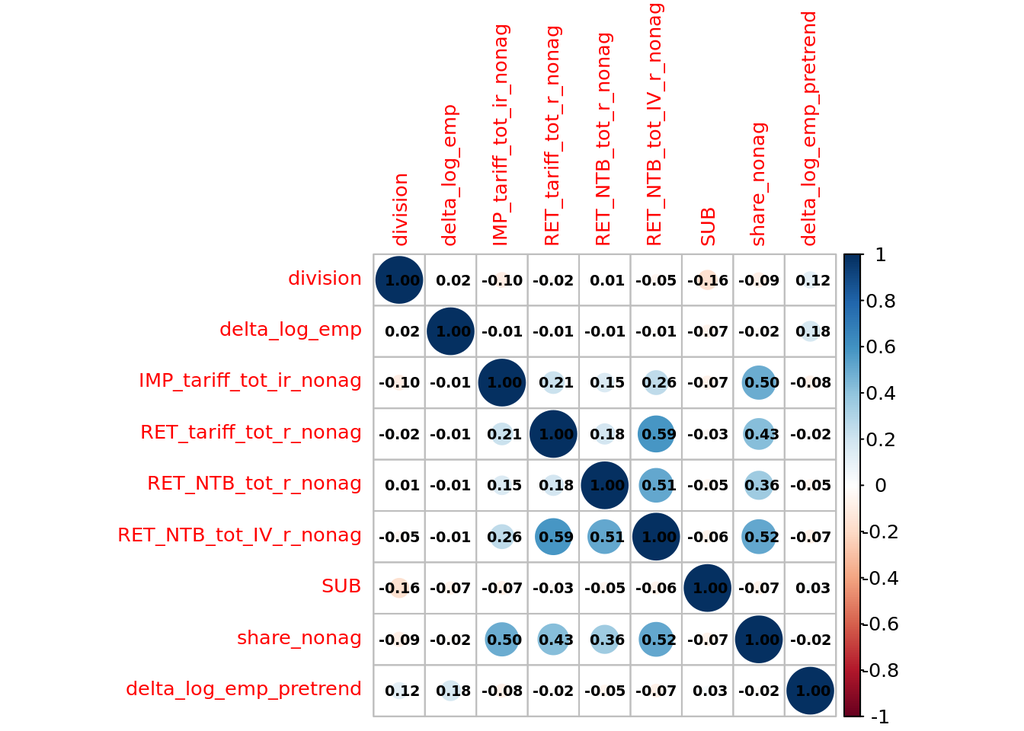

```
## NOTE: 317 observations removed because of NA values (LHS: 264, RHS: 198).
```

```
## NOTE: 317 observations removed because of NA values (LHS: 264, RHS: 200).
## NOTE: 317 observations removed because of NA values (LHS: 264, RHS: 200).
```

```
## NOTE: 319 observations removed because of NA values (LHS: 264, RHS: 300).
```

reg1

reg2

reg3

reg4

Dependent Var.:

delta_log_emp

delta_log_emp

delta_log_emp

delta_log_emp

IMP_tariff_tot_ir_nonag

-0.0150 (0.0189)

0.0077 (0.0281)

0.0190 (0.0280)

0.0486. (0.0279)

RET_tariff_tot_r_nonag

-0.0680 (0.1147)

0.0154 (0.1263)

0.0528 (0.1281)

0.0809 (0.1257)

RET_NTB_tot_r_nonag

-0.0252 (0.0512)

-0.0069 (0.0534)

-0.0040 (0.0534)

0.0320 (0.0505)

as.factor(year)2018 x share_nonag

-0.0789 (0.0871)

-0.0981 (0.0898)

-0.1357 (0.0876)

as.factor(year)2019 x share_nonag

-0.1365 (0.1447)

-0.1600 (0.1478)

-0.2422. (0.1457)

year x delta_log_emp_pretrend

6.67e-5*** (1.42e-5)

Fixed-Effects:

—————-

—————-

—————-

——————–

Year FE

Yes

Yes

Yes

Yes

Sector x year-month FE

No

Yes

Yes

Yes

Census division x year-month FE

No

No

Yes

Yes

Pre-trend CZ outcome 2017

No

No

No

Yes

year

Yes

Yes

Yes

Yes

_________________________________

________________

________________

________________

____________________

S.E.: Clustered

by: fips

by: fips

by: fips

by: fips

Observations

5,963

5,963

5,963

5,961

R2

0.00036

0.00064

0.00421

0.03405

Adj. R2

-0.00031

-0.00036

0.00052

0.03031

F-test

0.26848

0.32082

0.57414

4.5750

F-test, p-value

0.89836

0.92641

0.94255

3.12e-12

RMSE

0.35071

0.35066

0.35003

0.34396

```
## NOTE: 317 observations removed because of NA values (LHS: 264, RHS: 198).
```

```
## NOTE: 317 observations removed because of NA values (LHS: 264, RHS: 200).
## NOTE: 317 observations removed because of NA values (LHS: 264, RHS: 200).
```

```
## NOTE: 319 observations removed because of NA values (LHS: 264, RHS: 300).
```

reg1

reg2

reg3

reg4

Dependent Var.:

delta_log_emp

delta_log_emp

delta_log_emp

delta_log_emp

IMP_tariff_tot_ir_nonag

-0.0145 (0.0186)

0.0069 (0.0298)

0.0192 (0.0295)

0.0550. (0.0288)

RET_tariff_tot_r_nonag

-0.0085 (0.1226)

0.0281 (0.1267)

0.0527 (0.1275)

-0.0021 (0.1122)

RET_NTB_tot_IV_r_nonag

-0.0574 (0.0746)

-0.0153 (0.0866)

0.0002 (0.0866)

0.1014 (0.0815)

as.factor(year)2018 x share_nonag

-0.0779 (0.0887)

-0.1001 (0.0918)

-0.1492. (0.0890)

as.factor(year)2019 x share_nonag

-0.1309 (0.1572)

-0.1628 (0.1598)

-0.2890. (0.1545)

year x delta_log_emp_pretrend

6.71e-5*** (1.43e-5)

Fixed-Effects:

—————-

—————-

—————-

——————–

Year FE

Yes

Yes

Yes

Yes

Sector x year-month FE

No

Yes

Yes

Yes

Census division x year-month FE

No

No

Yes

Yes

Pre-trend CZ outcome 2017

No

No

No

Yes

year

Yes

Yes

Yes

Yes

_________________________________

________________

________________

________________

____________________

S.E.: Clustered

by: fips

by: fips

by: fips

by: fips

Observations

5,963

5,963

5,963

5,961

R2

0.00041

0.00065

0.00421

0.03423

Adj. R2

-0.00026

-0.00036

0.00052

0.03049

F-test

0.30421

0.32184

0.57396

4.5998

F-test, p-value

0.87529

0.92587

0.94265

2.5e-12

RMSE

0.35070

0.35066

0.35003

0.34393

# Log wage change

## Crop sector

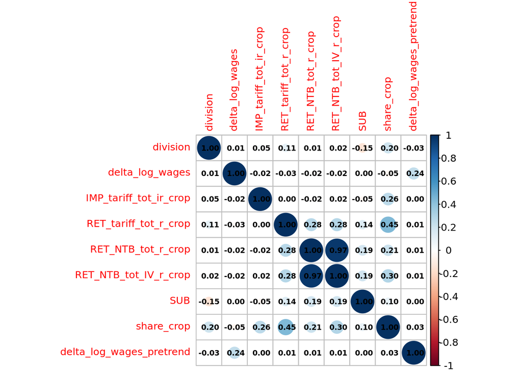

```
## NOTE: 885 observations removed because of NA values (LHS: 618, RHS: 732).
## NOTE: 885 observations removed because of NA values (LHS: 618, RHS: 732).
## NOTE: 885 observations removed because of NA values (LHS: 618, RHS: 732).
```

```
## NOTE: 902 observations removed because of NA values (LHS: 618, RHS: 868).
```

reg1

reg2

reg3

reg4

Dependent Var.:

delta_log_wages

delta_log_wages

delta_log_wages

delta_log_wages

IMP_tariff_tot_ir_crop

-0.3201. (0.1696)

-0.1454 (0.1540)

-0.1424 (0.1613)

-0.1254 (0.1579)

RET_tariff_tot_r_crop

-0.1070** (0.0393)

-0.0401 (0.0441)

-0.0357 (0.0458)

-0.0192 (0.0448)

RET_NTB_tot_r_crop

-0.0377 (0.0283)

-0.0240 (0.0267)

-0.0382 (0.0274)

-0.0386 (0.0276)

SUB

6.93e-6 (1.34e-5)

8.44e-6 (1.33e-5)

2.98e-5. (1.67e-5)

3.08e-5. (1.65e-5)

as.factor(year)2018 x share_crop

-0.6453** (0.2093)

-0.6882** (0.2412)

-0.9331*** (0.2375)

as.factor(year)2019 x share_crop

-0.9180** (0.3347)

-0.9752** (0.3331)

-1.263*** (0.3304)

year x delta_log_wages_pretrend

0.0001*** (1.81e-5)

Fixed-Effects:

——————

——————

——————

——————-

Year FE

Yes

Yes

Yes

Yes

Sector x year-month FE

No

Yes

Yes

Yes

Census division x year-month FE

No

No

Yes

Yes

Pre-trend CZ outcome 2017

No

No

No

Yes

year

Yes

Yes

Yes

Yes

________________________________

__________________

__________________

__________________

___________________

S.E.: Clustered

by: fips

by: fips

by: fips

by: fips

Observations

5,395

5,395

5,395

5,378

R2

0.00298

0.00429

0.00824

0.06927

Adj. R2

0.00206

0.00300

0.00399

0.06510

F-test

1.6157

1.6627

0.97536

8.3450

F-test, p-value

0.15237

0.11360

0.49459

1.53e-28

RMSE

0.67480

0.67436

0.67302

0.65246

```
## NOTE: 885 observations removed because of NA values (LHS: 618, RHS: 732).
```

```
## NOTE: 885 observations removed because of NA values (LHS: 618, RHS: 732).
## NOTE: 885 observations removed because of NA values (LHS: 618, RHS: 732).
```

```
## NOTE: 902 observations removed because of NA values (LHS: 618, RHS: 868).
```

reg1

reg2

reg3

reg4

Dependent Var.:

delta_log_wages

delta_log_wages

delta_log_wages

delta_log_wages

IMP_tariff_tot_ir_crop

-0.3149. (0.1687)

-0.1404 (0.1534)

-0.1377 (0.1607)

-0.1212 (0.1574)

RET_tariff_tot_r_crop

-0.1085** (0.0394)

-0.0444 (0.0435)

-0.0406 (0.0453)

-0.0239 (0.0445)

RET_NTB_tot_IV_r_crop

-0.0647 (0.0572)

-0.0133 (0.0550)

-0.0406 (0.0569)

-0.0450 (0.0575)

SUB

6.63e-6 (1.34e-5)

7.37e-6 (1.34e-5)

2.85e-5. (1.67e-5)

2.97e-5. (1.65e-5)

as.factor(year)2018 x share_crop

-0.6513** (0.2116)

-0.6883** (0.2437)

-0.9312*** (0.2397)

as.factor(year)2019 x share_crop

-0.9306** (0.3386)

-0.9801** (0.3381)

-1.264*** (0.3352)

year x delta_log_wages_pretrend

0.0001*** (1.81e-5)

Fixed-Effects:

——————

——————

——————

——————-

Year FE

Yes

Yes

Yes

Yes

Sector x year-month FE

No

Yes

Yes

Yes

Census division x year-month FE

No

No

Yes

Yes

Pre-trend CZ outcome 2017

No

No

No

Yes

year

Yes

Yes

Yes

Yes

________________________________

__________________

__________________

__________________

___________________

S.E.: Clustered

by: fips

by: fips

by: fips

by: fips

Observations

5,395

5,395

5,395

5,378

R2

0.00294

0.00424

0.00814

0.06918

Adj. R2

0.00202

0.00295

0.00389

0.06500

F-test

1.5948

1.6426

0.96336

8.3327

F-test, p-value

0.15808

0.11883

0.51106

1.73e-28

RMSE

0.67481

0.67437

0.67305

0.65250

## Livestock sector

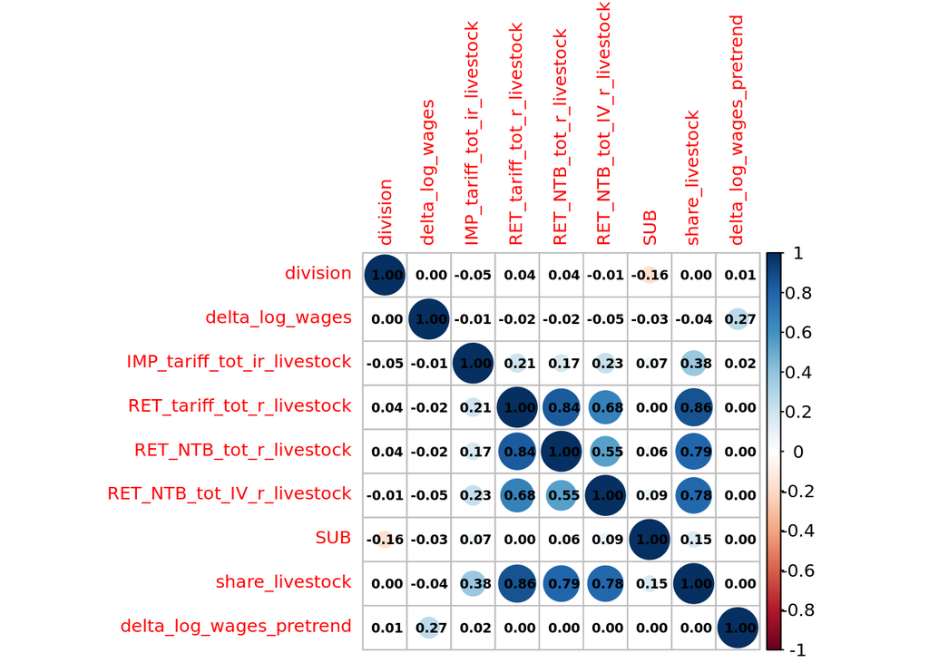

```
## NOTE: 1,777 observations removed because of NA values (LHS: 1,395, RHS: 1,480).
## NOTE: 1,777 observations removed because of NA values (LHS: 1,395, RHS: 1,480).
## NOTE: 1,777 observations removed because of NA values (LHS: 1,395, RHS: 1,480).
```

```
## NOTE: 1,793 observations removed because of NA values (LHS: 1,395, RHS: 1,732).
```

reg1

reg2

reg3

reg4

Dependent Var.:

delta_log_wages

delta_log_wages

delta_log_wages

delta_log_wages

IMP_tariff_tot_ir_livestock

-0.0137 (0.0987)

0.1384 (0.1260)

0.1532 (0.1310)

0.0798 (0.1297)

RET_tariff_tot_r_livestock

-0.1694 (0.3745)

0.5051 (0.4478)

0.4587 (0.4761)

0.2816 (0.4656)

RET_NTB_tot_r_livestock

-0.5991 (1.269)

0.0235 (1.279)

-0.0028 (1.349)

0.0752 (1.342)

SUB

-3.82e-5. (2.09e-5)

-2.65e-5 (2.06e-5)

-3.94e-5. (2.24e-5)

-3.37e-5 (2.25e-5)

as.factor(year)2018 x share_livestock

-1.020* (0.4186)

-1.123* (0.4376)

-0.9804* (0.4197)

as.factor(year)2019 x share_livestock

-0.9899. (0.5062)

-1.044* (0.5260)

-0.8672. (0.5045)

year x delta_log_wages_pretrend

0.0001*** (1.98e-5)

Fixed-Effects:

——————-

——————

——————-

——————-

Year FE

Yes

Yes

Yes

Yes

Sector x year-month FE

No

Yes

Yes

Yes

Census division x year-month FE

No

No

Yes

Yes

Pre-trend CZ outcome 2017

No

No

No

Yes

year

Yes

Yes

Yes

Yes

_____________________________________

___________________

__________________

___________________

___________________

S.E.: Clustered

by: fips

by: fips

by: fips

by: fips

Observations

4,503

4,503

4,503

4,487

R2

0.00136

0.00220

0.00651

0.07893

Adj. R2

0.00025

0.00064

0.00140

0.07398

F-test

0.61419

0.71028

0.64353

8.0410

F-test, p-value

0.68906

0.66338

0.90092

5.08e-27

RMSE

0.78145

0.78112

0.77944

0.74748

```
## NOTE: 1,777 observations removed because of NA values (LHS: 1,395, RHS: 1,480).
```

```
## NOTE: 1,777 observations removed because of NA values (LHS: 1,395, RHS: 1,480).
## NOTE: 1,777 observations removed because of NA values (LHS: 1,395, RHS: 1,480).
```

```
## NOTE: 1,793 observations removed because of NA values (LHS: 1,395, RHS: 1,732).
```

reg1

reg2

reg3

reg4

Dependent Var.:

delta_log_wages

delta_log_wages

delta_log_wages

delta_log_wages

IMP_tariff_tot_ir_livestock

0.0337 (0.1015)

0.0030 (0.1248)

0.0140 (0.1297)

-0.0551 (0.1292)

RET_tariff_tot_r_livestock

0.2410 (0.2297)

0.3693 (0.3559)

0.3375 (0.3790)

0.1808 (0.3770)

RET_NTB_tot_IV_r_livestock

-1.514* (0.5986)

-1.725* (0.7937)

-1.792* (0.7976)

-1.719* (0.7960)

SUB

-3.15e-5 (2.04e-5)

-2.82e-5 (2.07e-5)

-4.33e-5. (2.26e-5)

-3.75e-5. (2.26e-5)

as.factor(year)2018 x share_livestock

-0.3502 (0.4279)

-0.4524 (0.4337)

-0.3295 (0.4308)

as.factor(year)2019 x share_livestock

0.2585 (0.6460)

0.2137 (0.6456)

0.3491 (0.6449)

year x delta_log_wages_pretrend

0.0001*** (1.98e-5)

Fixed-Effects:

——————

——————

——————-

——————-

Year FE

Yes

Yes

Yes

Yes

Sector x year-month FE

No

Yes

Yes

Yes

Census division x year-month FE

No

No

Yes

Yes

Pre-trend CZ outcome 2017

No

No

No

Yes

year

Yes

Yes

Yes

Yes

_____________________________________

__________________

__________________

___________________

___________________

S.E.: Clustered

by: fips

by: fips

by: fips

by: fips

Observations

4,503

4,503

4,503

4,487

R2

0.00297

0.00335

0.00773

0.08007

Adj. R2

0.00186

0.00180

0.00264

0.07512

F-test

1.3480

1.0847

0.76579

8.1675

F-test, p-value

0.24116

0.37024

0.77743

1.47e-27

RMSE

0.78082

0.78067

0.77895

0.74702

## non ag

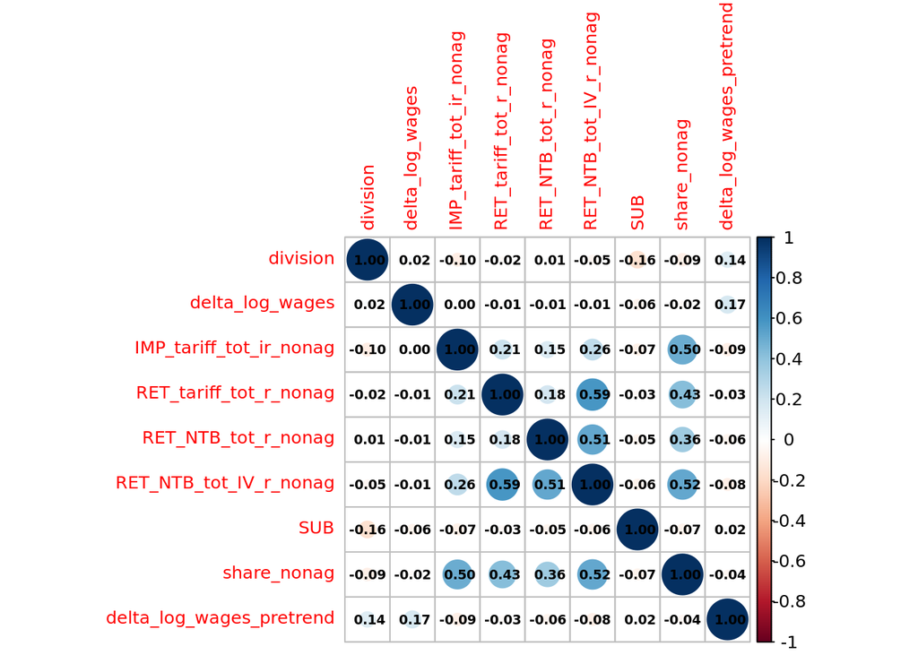

```
## NOTE: 317 observations removed because of NA values (LHS: 264, RHS: 198).
```

```
## NOTE: 317 observations removed because of NA values (LHS: 264, RHS: 200).
## NOTE: 317 observations removed because of NA values (LHS: 264, RHS: 200).
```

```
## NOTE: 319 observations removed because of NA values (LHS: 264, RHS: 300).
```

reg1

reg2

reg3

reg4

Dependent Var.:

delta_log_wages

delta_log_wages

delta_log_wages

delta_log_wages

IMP_tariff_tot_ir_nonag

-0.0060 (0.0215)

0.0221 (0.0299)

0.0384 (0.0301)

0.0717* (0.0309)

RET_tariff_tot_r_nonag

-0.1821 (0.1422)

-0.0782 (0.1438)

-0.0359 (0.1437)

0.0084 (0.1422)

RET_NTB_tot_r_nonag

-0.0341 (0.0546)

-0.0111 (0.0566)

-0.0092 (0.0574)

0.0290 (0.0554)

as.factor(year)2018 x share_nonag

-0.1020 (0.0956)

-0.1082 (0.0985)

-0.1367 (0.0972)

as.factor(year)2019 x share_nonag

-0.1680 (0.1544)

-0.1855 (0.1575)

-0.2655. (0.1575)

year x delta_log_wages_pretrend

6.06e-5*** (1.33e-5)

Fixed-Effects:

—————-

—————-

—————-

——————–

Year FE

Yes

Yes

Yes

Yes

Sector x year-month FE

No

Yes

Yes

Yes

Census division x year-month FE

No

No

Yes

Yes

Pre-trend CZ outcome 2017

No

No

No

Yes

year

Yes

Yes

Yes

Yes

_________________________________

________________

________________

________________

____________________

S.E.: Clustered

by: fips

by: fips

by: fips

by: fips

Observations

5,963

5,963

5,963

5,961

R2

0.00114

0.00148

0.00533

0.03358

Adj. R2

0.00047

0.00048

0.00165

0.02984

F-test

0.84924

0.73868

0.72759

4.5094

F-test, p-value

0.49384

0.61846

0.81501

5.6e-12

RMSE

0.39837

0.39830

0.39753

0.39100

```
## NOTE: 317 observations removed because of NA values (LHS: 264, RHS: 198).
```

```
## NOTE: 317 observations removed because of NA values (LHS: 264, RHS: 200).
## NOTE: 317 observations removed because of NA values (LHS: 264, RHS: 200).
```

```
## NOTE: 319 observations removed because of NA values (LHS: 264, RHS: 300).
```

reg1

reg2

reg3

reg4

Dependent Var.:

delta_log_wages

delta_log_wages

delta_log_wages

delta_log_wages

IMP_tariff_tot_ir_nonag

-0.0056 (0.0213)

0.0217 (0.0318)

0.0391 (0.0317)

0.0791* (0.0321)

RET_tariff_tot_r_nonag

-0.1129 (0.1344)

-0.0660 (0.1358)

-0.0372 (0.1361)

-0.0823 (0.1392)

RET_NTB_tot_IV_r_nonag

-0.0687 (0.0847)

-0.0148 (0.0991)

0.0019 (0.0995)

0.1109 (0.0973)

as.factor(year)2018 x share_nonag

-0.1031 (0.0986)

-0.1134 (0.1022)

-0.1543 (0.1009)

as.factor(year)2019 x share_nonag

-0.1657 (0.1699)

-0.1932 (0.1729)

-0.3208. (0.1708)

year x delta_log_wages_pretrend

6.1e-5*** (1.33e-5)

Fixed-Effects:

—————-

—————-

—————-

——————-

Year FE

Yes

Yes

Yes

Yes

Sector x year-month FE

No

Yes

Yes

Yes

Census division x year-month FE

No

No

Yes

Yes

Pre-trend CZ outcome 2017

No

No

No

Yes

year

Yes

Yes

Yes

Yes

_________________________________

________________

________________

________________

___________________

S.E.: Clustered

by: fips

by: fips

by: fips

by: fips

Observations

5,963

5,963

5,963

5,961

R2

0.00117

0.00148

0.00533

0.03377

Adj. R2

0.00050

0.00047

0.00164

0.03003

F-test

0.87527

0.73689

0.72684

4.5358

F-test, p-value

0.47785

0.61990

0.81582

4.43e-12

RMSE

0.39836

0.39830

0.39753

0.39097